# Exploration of the epigraphic formula `Dis manibus` on Latin inscriptions

Petra Hermankova[^1]

2022-03-31

```r
#install.packages(c("reticulate", "stringdist", "ape", "igraph", "tidyverse", "reticulate", "jsonlite", "leaflet"))

library(igraph)
library(ape)
library(stringdist)
library(tidyverse)
library(reticulate)
library(jsonlite)
library(leaflet)
#use_python("/usr/local/bin/python/") # use this if you have local python installed
#use_condaenv("pip")

Sys.which("python") # checks which python do I use
```

```
##                                                              python
## "/home/petra/.local/share/r-miniconda/envs/r-reticulate/bin/python"
```

Sources: # http://amunategui.github.io/stringdist/

```python
# installation of packages is recommended to do via the terminal (see in your console below), pip install name-of-the-required-package

# https://vincent.doba.fr/posts/20210407_install-fiona-on-windows/ & https://geopandas.org/getting_started/install.html Issues with geopandas on windows

#to install requirements type and run in the terminal:  pip install -r requirements.txt

import fiona
import geopandas as gpd
import requests
import seaborn as sns
import matplotlib.colors as mcolors
import matplotlib.pyplot as plt
from scipy.stats import trapz
import scipy
#import nltk
import json
import tempun
#import sddk
import numpy as np
import pandas as pd
pd.options.display.max_columns = 1000  # to see all columns
```

# 1 Setup

**Loading data from Sciencedata.dk**

```r
#list_json <- jsonlite::fromJSON("https://sciencedata.dk/public/b6b6afdb969d378b70929e86e58ad975/EDH_text_cleaned_2021-01-21.json")
#EDH <- as_tibble(list_json)
```

**Loading data locally**

```r
# this will work only if you have the dataset available locally
EDH <- jsonlite::fromJSON("../data/EDH_text_cleaned_2021-01-21.json")
#dir.create("../figures")
```

## 1.1 Text preparation

Converting the text of inscriptions to lowercase

```r
EDH <- EDH %>%
  mutate(clean_text_interpretive_word_lowercase = str_to_lower(EDH$clean_text_interpretive_word)) %>%
  mutate(clean_text_conservative_lowercase = str_to_lower(EDH$clean_text_conservative))
```

## 1.2 Preparation coordinates for mapping

```r
# preparation of coordinates
EDH<- EDH %>%
  separate(col = coordinates, into = c("longitude", "latitude"), sep = ",")
EDH$latitude <- as.numeric(str_replace(EDH$latitude, pattern = "\\)", replacement=""))
EDH$longitude <- as.numeric(str_replace(EDH$longitude, pattern = "c\\(", replacement=""))
```

# 2 Dis Manibus epigraphic formula in space and time

Typically occurs on funerary inscriptions, invocation of the underworld gods.

Canonic Versions:

D M - only in the conservative version of the text D M S - only in the conservative version Dis Manibus Diis Manibus Dis Manibus Sacrum Diis Manibus Sacrum

## 2.1 Extracting inscriptions with for all *typical* variants of the formula

```r
dis_manibus_regex_minimal <- "di{1,2}s manibus sacrum|di{1,2}s manibus"
dis_manibus_regex_maximal <- "\\bd m s\\b|\\bd m\\b|di{1,2}s manibus sacrum|di{1,2}s manibus|\\bdi{1,2} man[e|i]s\\b"

dis_manibus_int<- str_subset(EDH$clean_text_interpretive_word_lowercase, dis_manibus_regex_minimal)

dis_manibus_cons<- str_subset(EDH$clean_text_conservative_lowercase, dis_manibus_regex_maximal)


# separating them in a new attribute
EDH<- EDH %>%
  mutate(form_dis_manibus_ins = str_extract(EDH$clean_text_interpretive_word_lowercase, dis_manibus_regex_minimal)) %>%
  mutate(form_dis_manibus_cons = str_extract(EDH$clean_text_conservative_lowercase, dis_manibus_regex_maximal))

EDH$form_dis_manibus <- ifelse(grepl("\\w", EDH$form_dis_manibus_ins, ignore.case = T),  EDH$form_dis_manibus_ins, EDH$form_dis_manibus_cons)

EDH$form_dis_manibus <- ifelse(grepl("d m s", EDH$form_dis_manibus, ignore.case = T),  "dis manibus sacrum",
                               ifelse(grepl("d m", EDH$form_dis_manibus, ignore.case = T),  "dis manibus",
                               EDH$form_dis_manibus))

table(EDH$form_dis_manibus)
```

```
##
##            di manes           dii manes        diis manibus diis manibus sacrum
##                   2                   1                  75                  17
##         dis manibus  dis manibus sacrum
##                8712                3112
```

```r
# overview
table(str_extract(EDH$clean_text_interpretive_word_lowercase, dis_manibus_regex_minimal))
```

```
##
##        diis manibus diis manibus sacrum         dis manibus  dis manibus sacrum
##                  75                  17                8549                3102
```

```r
table(str_extract(EDH$clean_text_conservative_lowercase, dis_manibus_regex_maximal))
```

```
##
##                 d m               d m s            di manes            di manis
##                6671                2531                   2                   1
##           dii manes        diis manibus diis manibus sacrum         dis manibus
##                   1                  54                   7                 250
##  dis manibus sacrum
##                  20
```

```r
# capturing context - 5 words before the formula and 5 words after the formula
#EDH<- EDH %>%
#  mutate(dis_manibus_in_context_10w = str_extract(EDH$clean_text_interpretive_word_lowercase, "(\\w*\\s){0,6}di{1,2}s manibus sacrum|di{1,2}s manibus(\\w*\\s){0,6}"))
```

**Subsetting dataset to contain only records with formula**

```r
#non-empty dis manibus attribute
EDH_DM <- EDH %>%
  filter(!is.na(form_dis_manibus))
```

**Save the dataset locally**

```r
EDH_DMjson <- toJSON(EDH_DM, simplifyVector = TRUE)
write(EDH_DMjson, "../data/EDH_DM.json")
```

# 3 Exploration of Dis Manibus inscriptions

## 3.1 Formulae variants

### 3.1.1 Ratio of inscriptions with DM formula

```r
nrow(EDH %>%
  filter(!is.na(form_dis_manibus)))/(nrow(EDH)/100)
```

```
## [1] 14.62885
```

### 3.1.2 Type of all inscription with DM formula

```r
EDH_DM %>%
  count(type_of_inscription_clean, sort = T) %>%
  mutate(ratio = round(n/(sum(n)/100),2))
```

| type_of_inscription_clean | n | ratio |
| --- | --- | --- |
| epitaph | 9396 | 78.83 |
| NULL | 2386 | 20.02 |
| votive inscription | 96 | 0.81 |
| honorific inscription | 20 | 0.17 |
| list | 4 | 0.03 |
| building/dedicatory inscription | 3 | 0.03 |
| prayer | 3 | 0.03 |
| defixio | 2 | 0.02 |
| military diploma | 2 | 0.02 |
| owner/artist inscription | 2 | 0.02 |

[output cut: 4 more lines]

### 3.1.3 Ratio of funerary inscriptions with DM formula

```r
epitaph_all<- length(EDH$type_of_inscription_clean[EDH$type_of_inscription_clean == "epitaph"])
epitaph_dm<- length(EDH_DM$type_of_inscription_clean[EDH_DM$type_of_inscription_clean == "epitaph"])

epitaph_dm/(epitaph_all/100)
```

```
## [1] 33.61357
```

### 3.1.4 Type of the formula overall

```r
form_dm<- EDH_DM %>%
  #filter(type_of_inscription_clean %in% c("epitaph", "NULL")) %>%
  filter(!is.na(form_dis_manibus)) %>%
  count(form_dis_manibus, sort=T) %>%
  mutate(ratio = round(n/(sum(n)/100),2))

form_dm
```

| form_dis_manibus | n | ratio |
| --- | --- | --- |
| dis manibus | 8712 | 73.09 |
| dis manibus sacrum | 3112 | 26.11 |
| diis manibus | 75 | 0.63 |
| diis manibus sacrum | 17 | 0.14 |
| di manes | 2 | 0.02 |
| dii manes | 1 | 0.01 |

```r
write_csv(form_dm, "../output/DM_form_total_numbers.csv")
```

## 3.2 Province

### 3.2.1 Type of formula by province - frequence

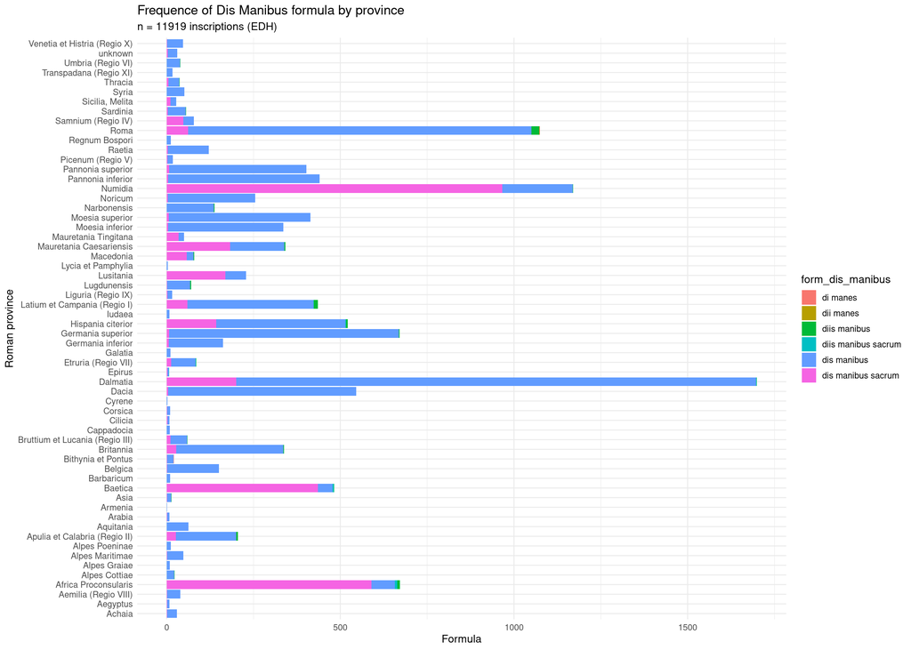

```r
EDM_DM_freq<- EDH_DM %>%
  #count(province_label_clean, form_dis_manibus, sort=T) %>%
  ggplot(aes(y=province_label_clean)) +
  geom_bar(aes(fill=form_dis_manibus)) +
  #coord_cartesian(xlim=c(0,1700)) +
  theme_minimal() +
  theme(text = element_text(size=12)) +
  labs(y="Roman province", x="Formula", title= "Frequence of Dis Manibus formula by province", subtitle = ggtitle(paste("n =", nrow(EDH_DM), "inscriptions (EDH)")))
ggsave("../figures/EDM_DM_province_freq.png")
EDM_DM_freq
```

### 3.2.2 Ratio of DM variants per province

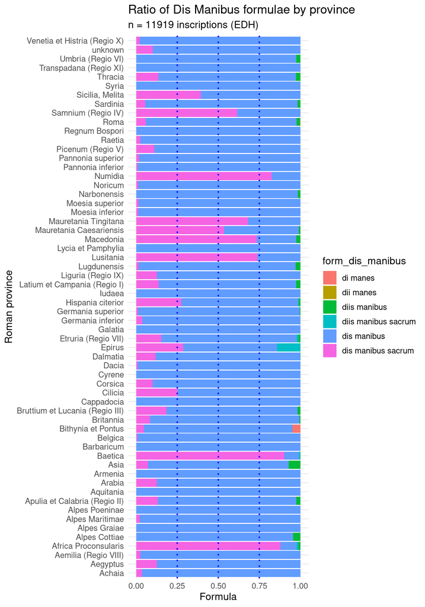

```r
DM_form<- EDH_DM %>%
  select(form_dis_manibus, province_label_clean) %>%
  count(form_dis_manibus, province_label_clean, sort=T)


EDH_DM %>%
  ggplot(aes(y=province_label_clean, fill=form_dis_manibus)) +
  geom_bar(position="fill") +
  theme_minimal() +
  theme(text = element_text(size=12)) +
  geom_vline(xintercept=c(0.25, 0.5, 0.75), linetype="dotted", color = "blue", size=0.8) +
  labs(y="Roman province", x="Formula", title= "Ratio of Dis Manibus formulae by province", subtitle = ggtitle(paste("n =", nrow(EDH_DM), "inscriptions (EDH)")))
```

```r
  #geom_label(aes(label= form_dis_manibus)) +
  #geom_label(aes(label = form_dis_manibus), colour = "black", fontface = "bold", hjust = -0.1)
```

### 3.2.3 Provinces with Dis manibus sacrum

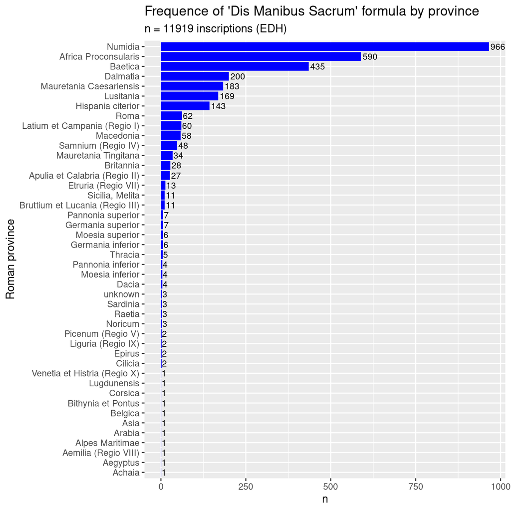

```r
EDH_DM$province_label_clean <-factor(EDH_DM$province_label_clean)

EDH_DM$form_dis_manibus <-factor(EDH_DM$form_dis_manibus)


EDH_DM %>%
  count(form_dis_manibus, province_label_clean, sort=T) %>%
  group_by(form_dis_manibus) %>%
  filter(form_dis_manibus == "dis manibus sacrum") %>%
  ggplot(aes(y=fct_reorder(province_label_clean, n), x=n)) +
  geom_col(fill= "blue") +
  labs(y="Roman province", x="n", title= "Frequence of 'Dis Manibus Sacrum' formula by province", subtitle = ggtitle(paste("n =", nrow(EDH_DM), "inscriptions (EDH)"))) +
  geom_text(aes(label = n), colour = "black", size= 3, hjust = -0.1)
```

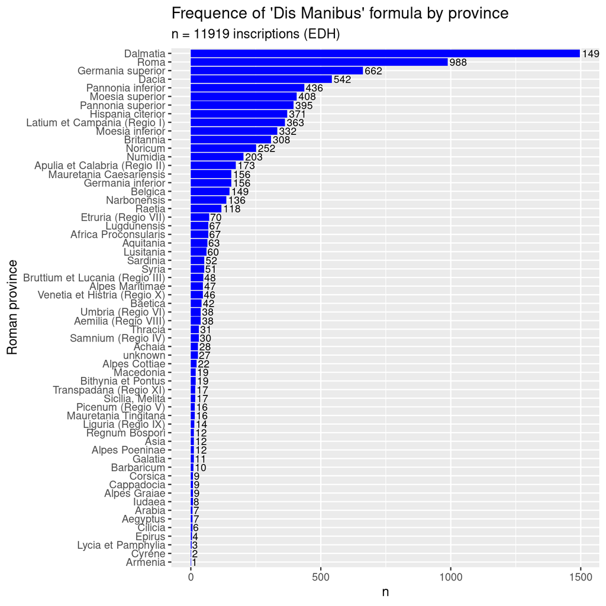

```r
EDH_DM %>%
  count(form_dis_manibus, province_label_clean, sort=T) %>%
  group_by(form_dis_manibus) %>%
  filter(form_dis_manibus == "dis manibus") %>%
  ggplot(aes(y=fct_reorder(province_label_clean, n), x=n)) +
  geom_col(fill= "blue") +
  labs(y="Roman province", x="n", title= "Frequence of 'Dis Manibus' formula by province", subtitle = ggtitle(paste("n =", nrow(EDH_DM), "inscriptions (EDH)"))) +
  geom_text(aes(label = n), colour = "black", size= 3, hjust = -0.1)
```

### 3.2.4 Ratio of formulae per province normalized by the number of total inscriptions

```r
DM_form_province<- EDH_DM %>%
  count(form_dis_manibus, province_label_clean, sort=T) %>%
  pivot_wider(names_from = form_dis_manibus, values_from = n)

province_total_insc<- EDH %>%
  count(province_label_clean)

provinces_DM<- merge(x=province_total_insc, y=DM_form_province, by="province_label_clean", all=T)

provinces_DM<- provinces_DM %>%
  rename(all_insc=n)

provinces_DM <- provinces_DM %>%
  mutate(dm = provinces_DM$`dis manibus`+provinces_DM$`diis manibus`) %>%
  mutate(dms = provinces_DM$`dis manibus sacrum`+provinces_DM$`diis manibus sacrum`) %>%
  mutate(dm_ratio = round(dm/(all_insc/100),2)) %>%
  mutate(dms_ratio = round(dms/(all_insc/100),2))

provinces_DM
```

| province_label_clean | all_insc | dis manibus | dis manibus sacrum | diis manibus | diis manibus sacrum | di manes | dii manes | dm | dms | dm_ratio | dms_ratio |
| --- | --- | --- | --- | --- | --- | --- | --- | --- | --- | --- | --- |
| Achaia | 1282 | 28 | 1 | NA | NA | NA | NA | NA | NA | NA | NA |
| Aegyptus | 167 | 7 | 1 | NA | NA | NA | NA | NA | NA | NA | NA |
| Aemilia (Regio VIII) | 211 | 38 | 1 | NA | NA | NA | NA | NA | NA | NA | NA |
| Africa Proconsularis | 4454 | 67 | 590 | 8 | 7 | NA | NA | 75 | 597 | 1.68 | 13.40 |
| Alpes Cottiae | 475 | 22 | NA | 1 | NA | NA | NA | 23 | NA | 4.84 | NA |
| Alpes Graiae | 76 | 9 | NA | NA | NA | NA | NA | NA | NA | NA | NA |
| Alpes Maritimae | 413 | 47 | 1 | NA | NA | NA | NA | NA | NA | NA | NA |
| Alpes Poeninae | 201 | 12 | NA | NA | NA | NA | NA | NA | NA | NA | NA |
| Apulia et Calabria (Regio II) | 761 | 173 | 27 | 5 | NA | NA | NA | 178 | NA | 23.39 | NA |
| Aquitania | 426 | 63 | NA | NA | NA | NA | NA | NA | NA | NA | NA |

[output cut: 55 more lines]

```r
write_csv(provinces_DM, "../output/DM_form_provinces.csv")
```

### 3.2.5 How common the dm and the dms formulae are (of all inscriptions from a given province)

```r
#Filter those provinces where the ratio is higher than mean for all provinces fro a given formula

higher_dm<- provinces_DM %>%
    filter(dm_ratio > mean(na.omit(provinces_DM$dm_ratio)))
higher_dm
```

| province_label_clean | all_insc | dis manibus | dis manibus sacrum | diis manibus | diis manibus sacrum | di manes | dii manes | dm | dms | dm_ratio | dms_ratio |
| --- | --- | --- | --- | --- | --- | --- | --- | --- | --- | --- | --- |
| Apulia et Calabria (Regio II) | 761 | 173 | 27 | 5 | NA | NA | NA | 178 | NA | 23.39 | NA |
| Bruttium et Lucania (Regio III) | 246 | 48 | 11 | 1 | NA | NA | NA | 49 | NA | 19.92 | NA |
| Dalmatia | 7650 | 1497 | 200 | 1 | 1 | NA | NA | 1498 | 201 | 19.58 | 2.63 |
| Latium et Campania (Regio I) | 2598 | 363 | 60 | 11 | 1 | NA | NA | 374 | 61 | 14.40 | 2.35 |
| Lugdunensis | 596 | 67 | 1 | 2 | NA | NA | NA | 69 | NA | 11.58 | NA |
| Mauretania Caesariensis | 1124 | 156 | 183 | 3 | NA | NA | NA | 159 | NA | 14.15 | NA |
| Roma | 4393 | 988 | 62 | 23 | NA | 1 | 1 | 1011 | NA | 23.01 | NA |
| Sardinia | 228 | 52 | 3 | 1 | NA | NA | NA | 53 | NA | 23.25 | NA |
| Umbria (Regio VI) | 348 | 38 | NA | 1 | NA | NA | NA | 39 | NA | 11.21 | NA |

```r
higher_dms<- provinces_DM %>%
    filter(dms_ratio > mean(na.omit(provinces_DM$dms_ratio)))
higher_dms
```

| province_label_clean | all_insc | dis manibus | dis manibus sacrum | diis manibus | diis manibus sacrum | di manes | dii manes | dm | dms | dm_ratio | dms_ratio |
| --- | --- | --- | --- | --- | --- | --- | --- | --- | --- | --- | --- |
| Africa Proconsularis | 4454 | 67 | 590 | 8 | 7 | NA | NA | 75 | 597 | 1.68 | 13.40 |
| Baetica | 3016 | 42 | 435 | 1 | 4 | NA | NA | 43 | 439 | 1.43 | 14.56 |

```r
higher_dm_dms<- provinces_DM %>%
    filter(dm_ratio > mean(na.omit(provinces_DM$dm_ratio)& dms_ratio > mean(na.omit(provinces_DM$dms_ratio))))
higher_dm_dms
```

| province_label_clean | all_insc | dis manibus | dis manibus sacrum | diis manibus | diis manibus sacrum | di manes | dii manes | dm | dms | dm_ratio | dms_ratio |
| --- | --- | --- | --- | --- | --- | --- | --- | --- | --- | --- | --- |

## 3.3 Mapping

### 3.3.1 Map of Dis Manibus occurences - cummulative

```r
# preparation of subsets
# dis manibus formula
EDH_dis_manibus <- EDH_DM %>%
  filter(form_dis_manibus == "dis manibus")

# diis manibus formula
EDH_diis_manibus <- EDH_DM %>%
  filter(form_dis_manibus == "diis manibus")

# dis manibus sacrum formula
EDH_dis_manibus_sacrum <- EDH_DM %>%
  filter(form_dis_manibus == "dis manibus sacrum")

# diis manibus sacrum formula
EDH_diis_manibus_sacrum <- EDH_DM %>%
  filter(form_dis_manibus == "diis manibus sacrum")
```

```r
DM_map<- #head(EDH_DM, 100) %>%
  leaflet(EDH_DM) %>%
  leaflet(width="100%") %>%
  #addProviderTiles("Stamen.Watercolor")%>% # Add CartoDB map tiles
  addProviderTiles("Stamen.TerrainBackground")%>% # Add CartoDB map tiles
  #addProviderTiles("Esri.WorldTopoMap", group = "Topo") %>%
  #addProviderTiles("Esri.WorldImagery", group = "ESRI Aerial") %>%
  setView( lng = 12.9239625, lat = 41.9515694, zoom = 3.5 ) %>%
  #setMaxBounds(lat1=43.633977, lng1 =-11.227926 , lat2=35.133882 , lng2=50.882336) %>%
  #addPolylines(data = roads, color = "purple", weight = 1, opacity = 0.7) %>%

  addCircles(lng = EDH_dis_manibus$longitude,
             lat = EDH_dis_manibus$latitude, opacity = 0.3, radius = 0.7, fill = T , color = "blue" , fillColor = "blue",) %>%
  addCircles(lng = EDH_dis_manibus_sacrum$longitude,
             lat = EDH_dis_manibus_sacrum$latitude, opacity = 0.3, radius = 0.7, fill = T , color = "red" , fillColor = "red",) %>%
    addCircles(lng = EDH_diis_manibus$longitude,
             lat = EDH_diis_manibus$latitude, opacity = 0.3, radius = 0.7, fill = T , color = "black" , fillColor = "black",) %>%
  addCircles(lng = EDH_diis_manibus_sacrum$longitude,
             lat = EDH_diis_manibus_sacrum$latitude, opacity = 0.3, radius = 0.7, fill = T , color = "orange" , fillColor = "orange",) %>%


  #addAwesomeMarkers(~EDH$longitude, ~EDH$latitude, icon=icons) %>%
  addLegend(position = "bottomright",
  colors = c("Blue", "Green", "Red", "Orange"),
  labels = c("dis manibus", "diis manibus", "dis manibus sacrum", "diis manibus sacrum"), opacity = 1,
  title = "Dis Manibus formula (EDH)"
) %>%
  addScaleBar(position="bottomleft")
DM_map
```

[interactive chart not shown]

## 3.4 Demographic preferences

**Preparation of the dataset - unique people records**

```r
EDH_small <- EDH_DM %>%
  select(id, people, form_dis_manibus, type_of_inscription_clean, type_of_monument_clean)

EDH_smu <- EDH_small %>% unnest_wider(people)
names(EDH_smu)
```

```
##  [1] "id"                        "name"
##  [3] "cognomen"                  "nomen"
##  [5] "person_id"                 "gender"
##  [7] "praenomen"                 "age: years"
##  [9] "status"                    "occupation"
## [11] "age: days"                 "age: months"
## [13] "origo"                     "tribus"
## [15] "age: hours"                "supernomen"
## [17] "form_dis_manibus"          "type_of_inscription_clean"
## [19] "type_of_monument_clean"
```

```r
# this works only on Linux computer, not on Windows

EDH_people<- EDH_small %>% unnest_wider(people) %>%
  unnest_longer(names(EDH_smu))
```

### 3.4.1 Gender of person on inscription

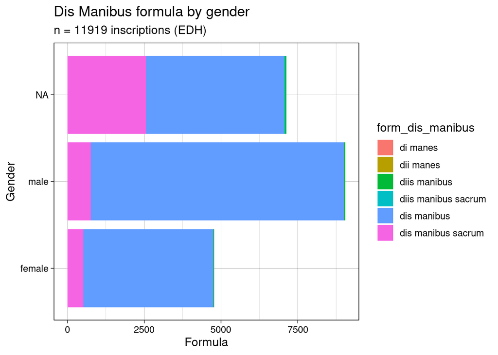

```r
EDH_people<- EDH_people %>%
  #filter(form_dis_manibus == "dis manibus" | form_dis_manibus == "dis manibus sacrum") %>%
  mutate(gender_clean = str_replace_all(gender, "W\\?", "female")) %>%
  mutate(gender_clean = str_replace_all(gender_clean, "M\\?", "male"))


EDH_people %>%
  count(gender_clean, form_dis_manibus, sort=T) %>%
  mutate(freq = n/(sum(n)/100)) %>%
  ggplot(aes(y=gender_clean, x=n)) +
  geom_col(aes(fill=form_dis_manibus)) +
  #geom_label(aes(label = round(freq, 2)), hjust=0.3, size = 3.5) +
  theme_linedraw(base_size = 12) +
  labs(y="Gender", x="Formula", title= "Dis Manibus formula by gender", subtitle = ggtitle(paste("n =", length(EDH_DM$people), "inscriptions (EDH)")))
```

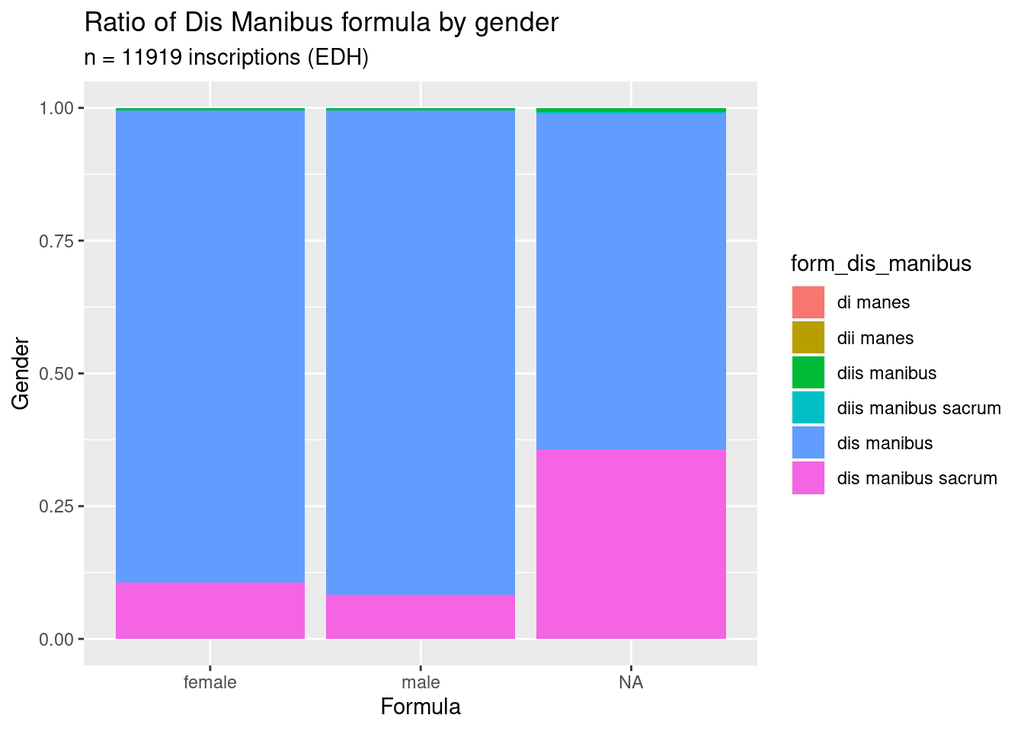

```r
EDH_people %>%
  ggplot(aes(x=gender_clean, fill=form_dis_manibus)) +
  geom_bar(position="fill") +
  #geom_label(aes(label = round(freq, 2)), hjust=0.3, size = 3.5) +
  #theme_linedraw(base_size = 12) +
  labs(y="Gender", x="Formula", title= "Ratio of Dis Manibus formula by gender", subtitle = ggtitle(paste("n =", length(EDH_DM$people), "inscriptions (EDH)")))
```

### 3.4.2 Status of person on inscription

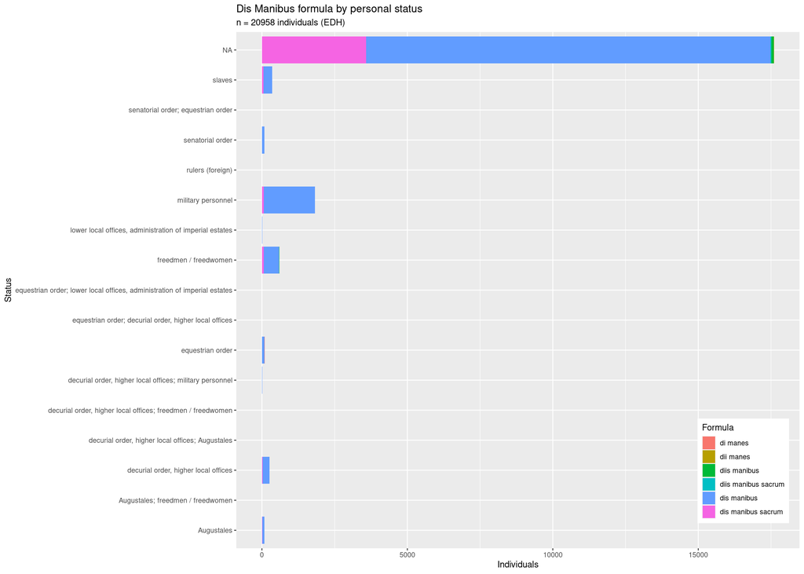

```r
EDH_people %>%
  #filter(form_dis_manibus == "dis manibus" | form_dis_manibus == "dis manibus sacrum") %>%
  mutate(status_clean = str_replace_all(status, "\\?", "")) %>%
  count(status_clean, form_dis_manibus, sort=T) %>%
  ggplot(aes(y=status_clean, x=n)) +
  geom_col(aes(fill=form_dis_manibus)) +
  #coord_cartesian(xlim = c(0, 15800)) +
  labs(y="Status", x="Individuals", title= "Dis Manibus formula by personal status", subtitle = ggtitle(paste("n =", nrow(EDH_people), "individuals (EDH)"))) +
  theme(legend.position = c(0.9, 0.15)) +
  scale_fill_discrete(name="Formula")
```

```r
EDH_people<- EDH_people %>%
  #filter(form_dis_manibus == "dis manibus" | form_dis_manibus == "dis manibus sacrum") %>%
  mutate(status_clean = str_replace_all(status, "\\?", ""))
```

Status of a person was split into new column `status_highest` that records only the highest status category in the following order: 1) slaves, 2) freedmen / freedwomen, 3) Augustales, 4) military personnel, 5) lower local offices, administration of imperial estates, 6) decurial order, high local offices, 7) equestrian order, 8) senatorial order, 9) rulers (foreign)

```r
EDH_people$status_highest <- ifelse(grepl("decurial order, higher local offices; military personnel", EDH_people$status_clean, ignore.case = T),  "decurial order, higher local offices",
                                    ifelse(grepl("equestrian order; decurial order, higher local offices", EDH_people$status_clean, ignore.case = T), "equestrian order",
                                           ifelse(grepl("senatorial order; equestrian order", EDH_people$status_clean, ignore.case = T), "senatorial order",
                                                  ifelse(grepl("Augustales; freedmen / freedwomen", EDH_people$status_clean, ignore.case = T), "Augustales",
                                                         ifelse(grepl("decurial order, higher local offices; Augustales", EDH_people$status_clean, ignore.case = T), "decurial order, higher local offices",
                                                                ifelse(grepl("decurial order, higher local offices; freedmen / freedwomen", EDH_people$status_clean, ignore.case = T), "decurial order, higher local offices",
                                                                       ifelse(grepl("equestrian order; lower local offices, administration of imperial estates", EDH_people$status_clean, ignore.case = T), "equestrian order",

                                                  EDH_people$status_clean)))))))
```

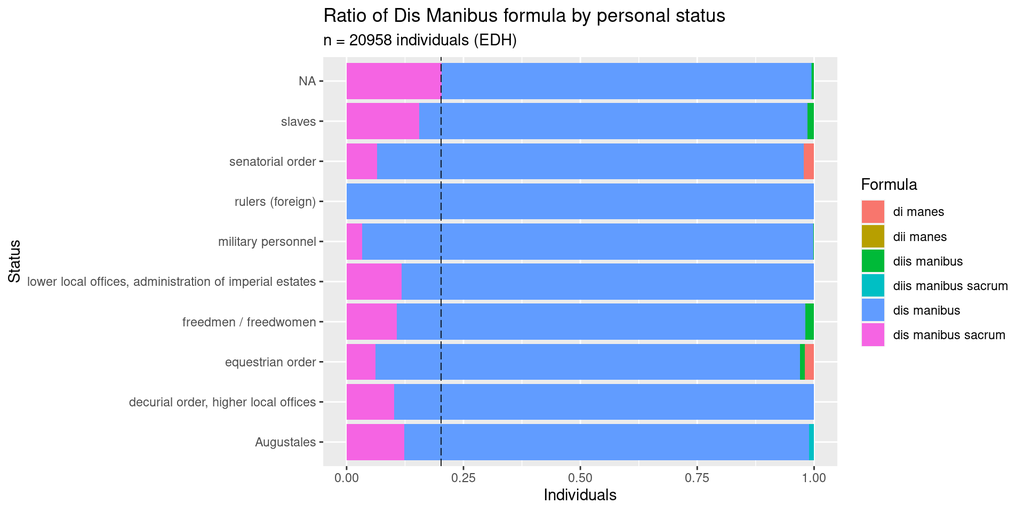

```r
EDH_status_count <- EDH_people %>%
  count(form_dis_manibus, status_clean, sort = T) %>%
  mutate(ratio = round(n/(sum(n)/100),2))

mean_dms <- mean(EDH_status_count$ratio[EDH_status_count$form_dis_manibus == "dis manibus sacrum"])

EDH_people %>%
  ggplot(aes(y=status_highest, fill=form_dis_manibus)) +
  geom_bar(position="fill") +
  #coord_cartesian(xlim = c(0, 15800)) +
  labs(y="Status", x="Individuals", title= "Ratio of Dis Manibus formula by personal status", subtitle = ggtitle(paste("n =", nrow(EDH_people), "individuals (EDH)"))) +
  #theme(legend.position = c(0.9, 0.15)) +
  scale_fill_discrete(name="Formula") +
  geom_vline(xintercept =mean_dms/10, linetype = "longdash", size=0.3)
```

### 3.4.3 Age of person on inscription

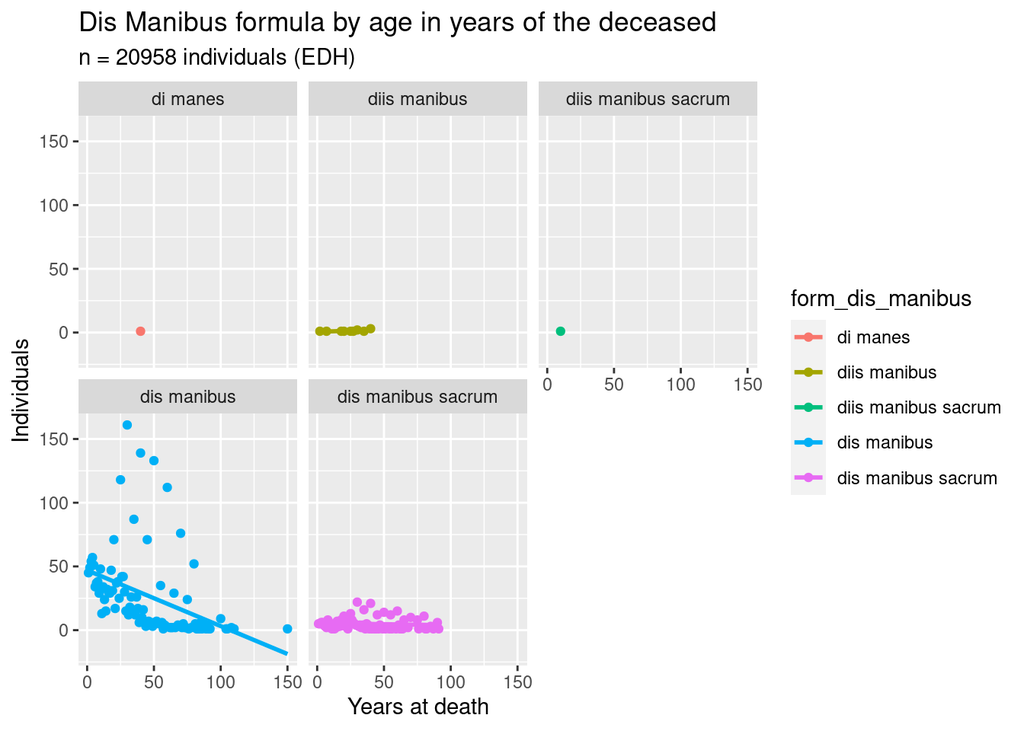

```r
EDH_people %>%
  mutate(age_yr = as.numeric(`age: years`)) %>%
  filter(!is.na(age_yr)) %>%
  count(age_yr, form_dis_manibus, sort=T) %>%
  ggplot(aes(age_yr, n, colour= form_dis_manibus)) +
  geom_point(aes(colour=form_dis_manibus)) +
  labs(y="Individuals", x="Years at death", title= "Dis Manibus formula by age in years of the deceased", subtitle = ggtitle(paste("n =", nrow(EDH_people), "individuals (EDH)")))+
  geom_smooth(se = FALSE, method = lm) +
  facet_wrap(~form_dis_manibus)
```

#### 3.4.3.1 Average age per formula type

```r
average_age <- EDH_people %>%
  mutate(age_yr = as.numeric(`age: years`)) %>%
  filter(!is.na(age_yr)) %>%
  select(age_yr)
average_age_all<- mean(na.omit(average_age$age_yr))

average_age_per_formula <- EDH_people %>%
  mutate(age_yr = as.numeric(`age: years`)) %>%
  filter(!is.na(age_yr)) %>%
  group_by(form_dis_manibus) %>%
  summarise_at(vars(age_yr), list(name=mean)) %>%
  mutate(diff_av_age  =  name-average_age_all)
average_age_per_formula
```

| form_dis_manibus | name | diff_av_age |
| --- | --- | --- |
| di manes | 40.00000 | 6.6621273 |
| diis manibus | 26.16667 | -7.1712060 |
| diis manibus sacrum | 10.00000 | -23.3378727 |
| dis manibus | 32.70337 | -0.6345009 |
| dis manibus sacrum | 37.75278 | 4.4149051 |

**Saving DM with people data locally:**

```r
EDH_DMpeoplejson <- toJSON(EDH_people, simplifyVector = TRUE)
write(EDH_DMpeoplejson, "../data/EDH_DM_people.json")
```

### 3.4.4 Inscribed monument

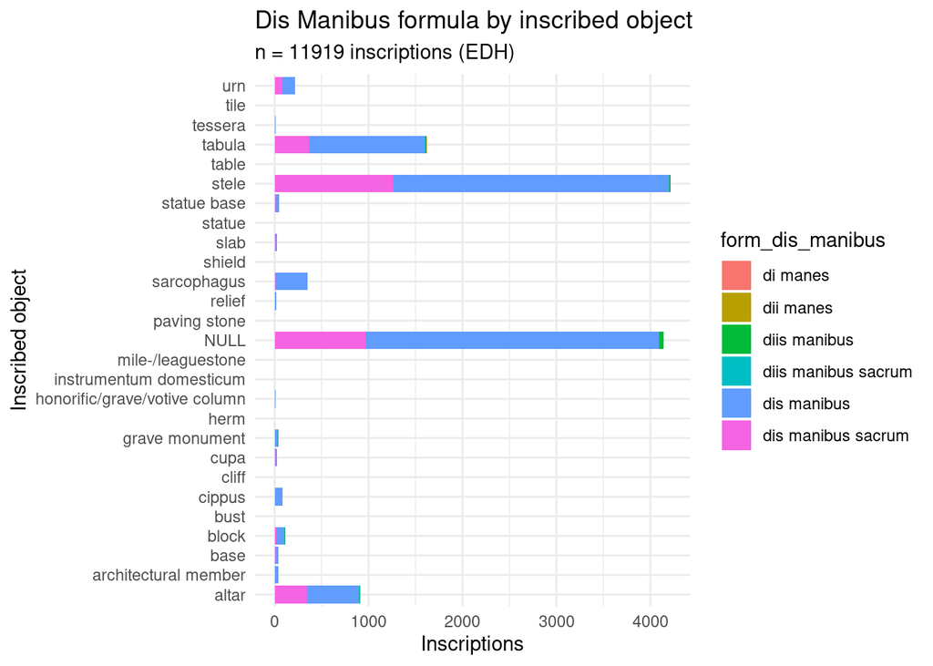

```r
EDH_DM %>%
  count(type_of_monument_clean, form_dis_manibus, sort = T) %>%
  ggplot(aes(y=type_of_monument_clean, x=n)) +
  geom_col(aes(fill=form_dis_manibus)) +
  theme_minimal() +
  labs(y="Inscribed object", x="Inscriptions", title= "Dis Manibus formula by inscribed object", subtitle = ggtitle(paste("n =", nrow(EDH_DM), "inscriptions (EDH)")))
```

### 3.4.5 Inscribed material

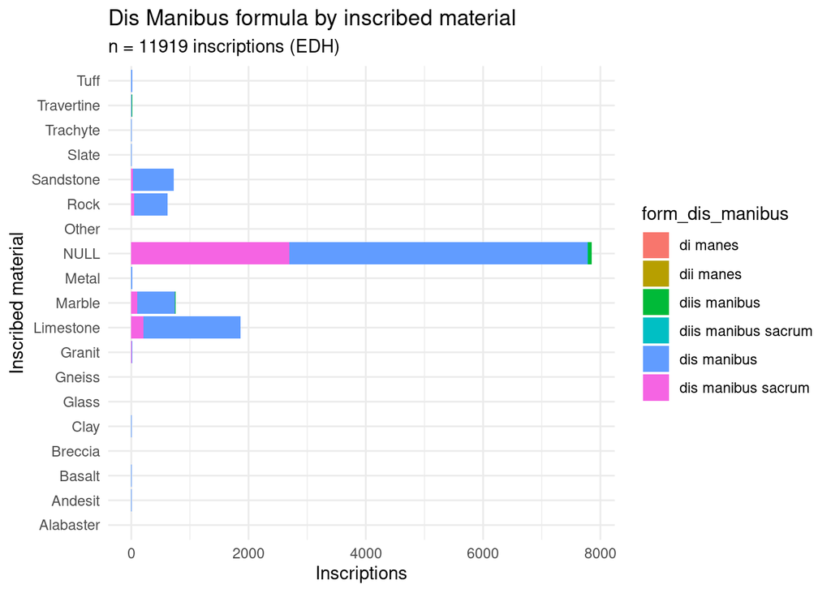

```r
EDH_DM %>%
  count(material_clean, form_dis_manibus, sort = T) %>%
  ggplot(aes(y=material_clean, x=n)) +
  geom_col(aes(fill=form_dis_manibus)) +
  theme_minimal() +
  labs(y="Inscribed material", x="Inscriptions", title= "Dis Manibus formula by inscribed material", subtitle = ggtitle(paste("n =", nrow(EDH_DM), "inscriptions (EDH)")))
```

[^1]: Aarhus University, Denmark, https://orcid.org/0000-0002-6349-0540